# CFA: Cultural Consumption at Cyprus

Victoria Bolotova

22 06 2022

```r
load("Cyprus.RData")
```

# Task 1

```r
library(dplyr)
efa <- Cyprus %>%
  select(opera, cinema, theatre, concert, lib, sites, museum, tv, books)
```

## Checking data adequacy

### KMO

```r
library(psych)
KMO(efa)
```

```
## Kaiser-Meyer-Olkin factor adequacy
## Call: KMO(r = efa)
## Overall MSA =  0.81
## MSA for each item =
##   opera  cinema theatre concert     lib   sites  museum      tv   books
##    0.79    0.76    0.83    0.81    0.84    0.80    0.85    0.71    0.82
```

- Average KMO equals to 0.81, which is a good result.

### Bartlett test of Sphericity

The null hypotheses is that the variance-covariance matrix is an identity matrix (variables are uncorrelated).

```r
r <- cor(efa)
cortest.bartlett(r)
```

```
## $chisq
## [1] 185.7231
##
## $p.value
## [1] 4.565238e-22
##
## $df
## [1] 36
```

- P-value indicates significant result, which is good. It means that our variables are correlated.
- According to tests above, we can conclude that we can use this data for FA.

## Choose the number of factors

### Eigenvalues

- Should be above 1

```r
ev <- eigen(r)
ev$values
```

```
## [1] 3.2443383 1.2536701 0.9472578 0.8487411 0.7106847 0.5608339 0.5024244
## [8] 0.4818769 0.4501727
```

- Only 2 variables have eigenvalues higher than 1. Thus, it tells us that we should extract 2 factors.

### Parallel Analysis screen plot

- Helps determine the number of factors

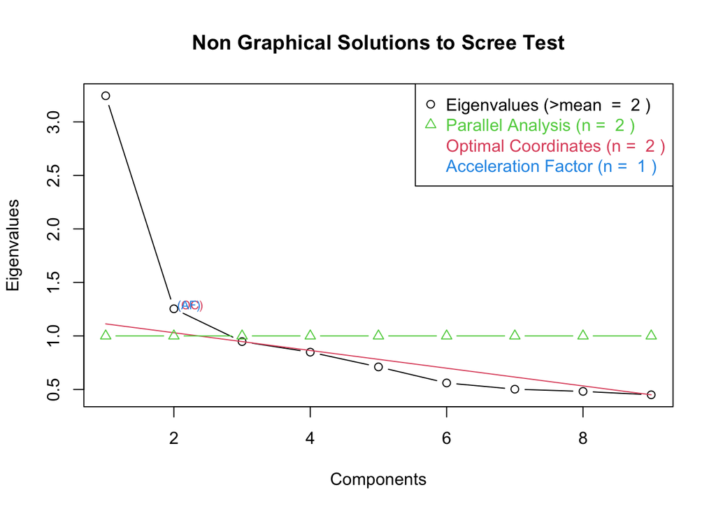

```r
library(nFactors)
nS <- nScree(x=ev$values)#get data for scree plot
plotnScree(nS)
```

- Most tests say we should extract 2 factors

## Models

### With all variables

```r
library(GPArotation)
fit1  = fa(efa, nfactors = 2, n.iter = 100, fm = "ml")
fit1
```

```
## Factor Analysis with confidence intervals using method = fa(r = efa, nfactors = 2, n.iter = 100, fm = "ml")
## Factor Analysis using method =  ml
## Call: fa(r = efa, nfactors = 2, n.iter = 100, fm = "ml")
## Standardized loadings (pattern matrix) based upon correlation matrix
##           ML1   ML2   h2   u2 com
## opera    0.46  0.11 0.27 0.73 1.1
## cinema   0.60 -0.12 0.31 0.69 1.1
## theatre  0.63  0.06 0.44 0.56 1.0
## concert  0.76 -0.01 0.56 0.44 1.0
## lib      0.19  0.29 0.17 0.83 1.7
## sites    0.03  0.61 0.39 0.61 1.0
## museum   0.40  0.38 0.45 0.55 2.0
## tv      -0.10  0.66 0.38 0.62 1.0
## books    0.17  0.44 0.30 0.70 1.3
##
##                        ML1  ML2
## SS loadings           1.90 1.38
## Proportion Var        0.21 0.15
## Cumulative Var        0.21 0.36
## Proportion Explained  0.58 0.42
## Cumulative Proportion 0.58 1.00
##
##  With factor correlations of
##      ML1  ML2
## ML1 1.00 0.48
## ML2 0.48 1.00
##
## Mean item complexity =  1.3
## Test of the hypothesis that 2 factors are sufficient.
##
## The degrees of freedom for the null model are  36  and the objective function was  1.95 with Chi Square of  806.32
## The degrees of freedom for the model are 19  and the objective function was  0.18
##
## The root mean square of the residuals (RMSR) is  0.05
## The df corrected root mean square of the residuals is  0.07
##
## The harmonic number of observations is  418 with the empirical chi square  67.58  with prob <  2.3e-07
## The total number of observations was  418  with Likelihood Chi Square =  74.27  with prob <  1.8e-08
##
## Tucker Lewis Index of factoring reliability =  0.864
```

[output cut: 9 more lines]

```
##  Coefficients and bootstrapped confidence intervals
##           low   ML1 upper   low   ML2 upper
## opera    0.18  0.46  0.77 -0.20  0.11  0.55
## cinema   0.34  0.60  0.77 -0.32 -0.12  0.19
## theatre  0.42  0.63  0.82 -0.11  0.06  0.36
## concert  0.52  0.76  0.92 -0.17 -0.01  0.26
## lib     -0.06  0.19  0.49  0.05  0.29  0.58
## sites   -0.09  0.03  0.30  0.38  0.61  0.80
## museum   0.15  0.40  0.70  0.13  0.38  0.76
## tv      -0.27 -0.10  0.17  0.36  0.66  0.97
## books    0.08  0.17  0.37  0.25  0.44  0.59
##
##  Interfactor correlations and bootstrapped confidence intervals
##         lower estimate upper
## ML1-ML2  0.24     0.48   0.6
```

- Interpretation:
  - Acceptable cumulative var (0.36), but still it is low. It means that 36% of variance is explained by 2 factors (should be > 0.5 to be good result)
  - RMSR is 0.05, which is acceptable
  - RMSEA index equals to 0.083, which is too high, unfortunately (<.08 acceptable, <.05 excellent)
  - Tucker Lewis Index is close to acceptable (0.86) (>.90 acceptable, >.95 excellent)
  - Mean item complexity 1.3, which is pretty good
  - As for Proportion Var and Proportion Explained, everything is looking good. As for Proportion Var (proportion of variance which is explained by each factor), the last factor (MR2) explains 15% of variance. According to the rule of thumb, one factor should explain at least 10% of variance. Thus, it indicates that we should not reduce the number of factors.
- Loadings:
  - lib does not have factor loadings higher than 0.29, moreover, its uniqueness is very high (0.83)
  - we also have problems with museum variable because it has very similar factor loadings (0.4 and 0.38), which is not acceptable
  - other manifest variables have good factor loadings
  - thus, it is necessary to delete only 2 variables: lib and museum
- Rotations did not help in improving the model

### Without 2 variables

```r
efa_7 <- efa %>%
  select(- lib, - museum)
```

```r
library(GPArotation)
fit2  = fa(efa_7, nfactors = 2, n.iter = 100, fm = "ml")
fit2
```

```
## Factor Analysis with confidence intervals using method = fa(r = efa_7, nfactors = 2, n.iter = 100, fm = "ml")
## Factor Analysis using method =  ml
## Call: fa(r = efa_7, nfactors = 2, n.iter = 100, fm = "ml")
## Standardized loadings (pattern matrix) based upon correlation matrix
##           ML2   ML1   h2   u2 com
## opera    0.50 -0.02 0.24 0.76 1.0
## cinema   0.56 -0.07 0.30 0.70 1.0
## theatre  0.66  0.05 0.45 0.55 1.0
## concert  0.76 -0.01 0.58 0.42 1.0
## sites    0.21  0.39 0.25 0.75 1.5
## tv      -0.03  0.89 0.77 0.23 1.0
## books    0.28  0.37 0.28 0.72 1.9
##
##                        ML2  ML1
## SS loadings           1.74 1.13
## Proportion Var        0.25 0.16
## Cumulative Var        0.25 0.41
## Proportion Explained  0.61 0.39
## Cumulative Proportion 0.61 1.00
##
##  With factor correlations of
##     ML2 ML1
## ML2 1.0 0.3
## ML1 0.3 1.0
##
## Mean item complexity =  1.2
## Test of the hypothesis that 2 factors are sufficient.
##
## The degrees of freedom for the null model are  21  and the objective function was  1.32 with Chi Square of  545.06
## The degrees of freedom for the model are 8  and the objective function was  0.07
##
## The root mean square of the residuals (RMSR) is  0.04
## The df corrected root mean square of the residuals is  0.06
##
## The harmonic number of observations is  418 with the empirical chi square  28.09  with prob <  0.00046
## The total number of observations was  418  with Likelihood Chi Square =  30.22  with prob <  0.00019
##
## Tucker Lewis Index of factoring reliability =  0.888
## RMSEA index =  0.081  and the 90 % confidence intervals are  0.052 0.114
## BIC =  -18.07
## Fit based upon off diagonal values = 0.98
## Measures of factor score adequacy
##                                                    ML2  ML1
## Correlation of (regression) scores with factors   0.87 0.89
## Multiple R square of scores with factors          0.76 0.80
## Minimum correlation of possible factor scores     0.52 0.60
##
##  Coefficients and bootstrapped confidence intervals
##           low   ML2 upper   low   ML1 upper
## opera    0.35  0.50  0.65 -0.14 -0.02  0.12
## cinema   0.40  0.56  0.70 -0.19 -0.07  0.07
## theatre  0.52  0.66  0.81 -0.08  0.05  0.17
## concert  0.59  0.76  0.91 -0.13 -0.01  0.12
## sites    0.08  0.21  0.32  0.24  0.39  0.60
## tv      -0.09 -0.03  0.09  0.64  0.89  1.07
## books    0.18  0.28  0.37  0.24  0.37  0.54
##
##  Interfactor correlations and bootstrapped confidence intervals
##         lower estimate upper
## ML2-ML1  0.17      0.3  0.44
```

- Interpretation:
  - Cumulative var becomes higher (from 0.36 to 0.41). It means that 41% of variance is explained by 2 factors (should be > 0.5 to be good result)
  - RMSR also becomes better (from 0.05 to 0.04), which is good
  - RMSEA index equals to 0.081, which is still too high, unfortunately, but acceptable (<.08 acceptable, <.05 excellent). It also become better after deleting 2 variables (was 0.083)
  - Tucker Lewis Index is very close to acceptable (0.88) (>.90 acceptable, >.95 excellent), also becomes a little bit better
  - Mean item complexity 1.2, which is pretty good. For previous model is was 1.3
  - As for Proportion Var and Proportion Explained, everything is looking good.
- Now all factor loadings looks pretty good!
- Rotations did not help in improving the model

## Visualisation

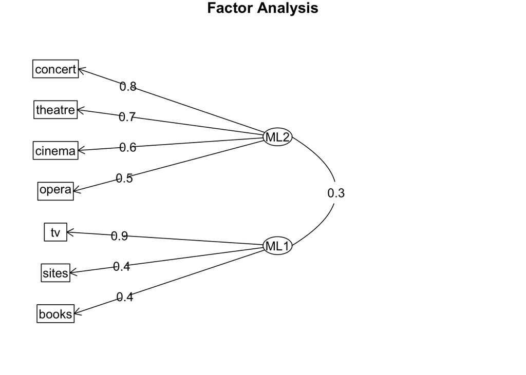

```r
fa.diagram(fit2)
```

- ML2: Getting out from home for cultural consumption - outside. For extroverts
  - concert
  - theatre
  - cinema
  - opera
- ML1: Cultural consumption at home (except for sites) - inside. For introverts
  - tv
  - sites
  - books

I think that sites also entered to this factor, because it is kinda static form of culture (not so lively as concert, theatre, cinema, opera). May be it is not so crowed as places such as concert, opera, etc. That is why people who prefer cultural consumption at home, also prefer visiting sites. May be these people are more introverts, than those who like concerts, theaters, cinemas and operas.

# Task 2

## Specification of the model

```r
library(lavaan)

model1 <- '
for_extroverts =~ opera + cinema + theatre + concert
for_introverts =~ sites + tv + books
'
```

## CFA

```r
fit1 = cfa(model1, data = efa_7)
summary(fit1, standardized=TRUE, fit.measures=TRUE, modindices=TRUE)
```

```
## lavaan 0.6-12 ended normally after 35 iterations
##
##   Estimator                                         ML
##   Optimization method                           NLMINB
##   Number of model parameters                        15
##
##   Number of observations                           418
##
## Model Test User Model:
##
##   Test statistic                                52.210
##   Degrees of freedom                                13
##   P-value (Chi-square)                           0.000
##
## Model Test Baseline Model:
##
##   Test statistic                               550.551
##   Degrees of freedom                                21
##   P-value                                        0.000
##
## User Model versus Baseline Model:
##
##   Comparative Fit Index (CFI)                    0.926
##   Tucker-Lewis Index (TLI)                       0.880
##
## Loglikelihood and Information Criteria:
##
##   Loglikelihood user model (H0)              -3116.048
##   Loglikelihood unrestricted model (H1)      -3089.943
##
##   Akaike (AIC)                                6262.096
##   Bayesian (BIC)                              6322.628
##   Sample-size adjusted Bayesian (BIC)         6275.029
##
## Root Mean Square Error of Approximation:
##
##   RMSEA                                          0.085
##   90 Percent confidence interval - lower         0.062
##   90 Percent confidence interval - upper         0.110
##   P-value RMSEA <= 0.05                          0.008
```

[output cut: 56 more lines]

```
## 14         cinema ~~ theatre  0.801 -0.020  -0.020   -0.068   -0.068
## 15         cinema ~~ concert 20.290  0.097   0.097    0.391    0.391
## 16         cinema ~~   sites  1.450 -0.031  -0.031   -0.068   -0.068
## 17         cinema ~~      tv  2.341 -0.056  -0.056   -0.091   -0.091
## 18         cinema ~~   books  0.871  0.032   0.032    0.054    0.054
## 19        theatre ~~ concert 13.009 -0.089  -0.089   -0.487   -0.487
## 20        theatre ~~   sites  0.126  0.007   0.007    0.022    0.022
## 21        theatre ~~      tv  0.375  0.018   0.018    0.041    0.041
## 22        theatre ~~   books  0.005 -0.002  -0.002   -0.005   -0.005
## 23        concert ~~   sites  0.044  0.004   0.004    0.014    0.014
## 24        concert ~~      tv  2.592 -0.045  -0.045   -0.115   -0.115
## 25        concert ~~   books  3.275  0.046   0.046    0.124    0.124
## 26          sites ~~      tv  8.429  0.226   0.226    0.312    0.312
## 27          sites ~~   books 15.945 -0.264  -0.264   -0.379   -0.379
## 28             tv ~~   books  1.378  0.133   0.133    0.142    0.142
```

- Tucker-Lewis Index (TLI) is close to acceptable (0.88)
- Comparative Fit Index (CFI) is also very close to acceptable (0.93)
- RMSEA index equals to 0.085 (<.08 acceptable, <.05 excellent), which is close to acceptable
- SRMR equals to 0.051, which is reasonably close fit.

## Find problematic parameteris by MI and EPC

- MI (threshold is 3.84 - should be less than this value) shows how Chi-square would change if we estimate some additional parameters.
- EPC shows us the value to what the corresponding parameter equals to (correlation). Standardized EPC |0.2| indicate problematic misspecifications.

```r
mi_1 <- modindices(fit1)
mi_1[mi_1$mi > 3.84, 1:5]
```

```
##               lhs op     rhs     mi    epc
## 19 for_extroverts =~      tv 15.945 -2.213
## 20 for_extroverts =~   books  8.429  1.403
## 25          opera ~~  cinema 12.246 -0.045
## 26          opera ~~ theatre 16.003  0.047
## 28          opera ~~   sites  4.365  0.030
## 32         cinema ~~ concert 20.290  0.097
## 36        theatre ~~ concert 13.009 -0.089
## 43          sites ~~      tv  8.429  0.226
## 44          sites ~~   books 15.945 -0.264
```

- The highest modification indices (correlations) have parameters:
  - cinema ~~ concert 20.290 and 0.097
  - sites ~~ books 15.945 and -0.264
  - opera ~~ theater 16.003 and 0.047

## Improve the model

```r
model2 <- '
for_extroverts =~ opera + cinema + theatre + concert
for_introverts =~ sites + tv + books
cinema ~~ concert
opera ~~ theatre
sites ~~   books
'
```

```r
fit2 = cfa(model2, data = efa_7)
summary(fit2, standardized=TRUE, fit.measures=TRUE, modindices=TRUE)
```

```
## lavaan 0.6-12 ended normally after 44 iterations
##
##   Estimator                                         ML
##   Optimization method                           NLMINB
##   Number of model parameters                        18
##
##   Number of observations                           418
##
## Model Test User Model:
##
##   Test statistic                                14.796
##   Degrees of freedom                                10
##   P-value (Chi-square)                           0.140
##
## Model Test Baseline Model:
##
##   Test statistic                               550.551
##   Degrees of freedom                                21
##   P-value                                        0.000
##
## User Model versus Baseline Model:
##
##   Comparative Fit Index (CFI)                    0.991
##   Tucker-Lewis Index (TLI)                       0.981
##
## Loglikelihood and Information Criteria:
##
##   Loglikelihood user model (H0)              -3097.341
##   Loglikelihood unrestricted model (H1)      -3089.943
##
##   Akaike (AIC)                                6230.682
##   Bayesian (BIC)                              6303.320
##   Sample-size adjusted Bayesian (BIC)         6246.201
##
## Root Mean Square Error of Approximation:
##
##   RMSEA                                          0.034
##   90 Percent confidence interval - lower         0.000
##   90 Percent confidence interval - upper         0.068
##   P-value RMSEA <= 0.05                          0.748
```

[output cut: 58 more lines]

```
## 10          opera ~~      tv 2.192 -0.030  -0.030   -0.075   -0.075
## 11          opera ~~   books 0.023  0.003   0.003    0.011    0.011
## 12         cinema ~~ theatre 5.522  0.053   0.053    0.173    0.173
## 13         cinema ~~   sites 1.126 -0.027  -0.027   -0.071   -0.071
## 14         cinema ~~      tv 0.450 -0.024  -0.024   -0.033   -0.033
## 15         cinema ~~   books 0.417  0.022   0.022    0.046    0.046
## 16        theatre ~~ concert 2.021 -0.034  -0.034   -0.176   -0.176
## 17        theatre ~~   sites 1.071 -0.024  -0.024   -0.088   -0.088
## 18        theatre ~~      tv 3.266  0.056   0.056    0.108    0.108
## 19        theatre ~~   books 1.060 -0.033  -0.033   -0.096   -0.096
## 20        concert ~~   sites 0.038 -0.004  -0.004   -0.017   -0.017
## 21        concert ~~      tv 0.102 -0.009  -0.009   -0.020   -0.020
## 22        concert ~~   books 0.941  0.028   0.028    0.094    0.094
## 23          sites ~~      tv 0.633  0.075   0.075    0.116    0.116
## 24             tv ~~   books 0.633 -0.105  -0.105   -0.131   -0.131
```

- Tucker-Lewis Index (TLI) becomes much better, now it is very good (0.98)
- Comparative Fit Index (CFI) also becomes much better, now it is very good (0.99)
- RMSEA index equals to 0.034 (<.08 acceptable, <.05 excellent), which is excellent now
- SRMR equals to 0.025, which indicates very good fit.

-> In accordance with above indexes, the model is very good!

- To sum up, model become better after adding correlation among variables that is not fully explained by one common factor.
- However, to be sure that the second model is significantly better than the first one we should run anova.

## Anova

```r
anova(fit1, fit2)
```

```
## Chi-Squared Difference Test
##
##      Df    AIC    BIC  Chisq Chisq diff Df diff Pr(>Chisq)
## fit2 10 6230.7 6303.3 14.796
## fit1 13 6262.1 6322.6 52.210     37.414       3  3.761e-08 ***
## ---
## Signif. codes:  0 '***' 0.001 '**' 0.01 '*' 0.05 '.' 0.1 ' ' 1
```

- Anova result shows that the second model is significantly better than the first one. It means that the second model explains data better, than the first one.
- We have lost 3 degree of freedom
- Chi-square’s difference is 37, which is pretty high
- Thus, the second model is better

# Task 3

## Saving factor scores

```r
Cyprus[,14:15] <- lavPredict(fit2, method = "regression")
colnames(Cyprus)[14:15] <- c("for_extroverts", "for_introverts")
```

## For extroverts

```r
labs <- c("Constant", "Gender (Female)", "Age when completed education", "Employment status (Employed)", "Employment status (Not working)", "Age")
mod1 <- lm(for_extroverts ~ gender + edu + stat2 + age, data = Cyprus)
library(sjPlot)
tab_model(mod1, pred.labels = labs, dv.labels = "Activities for extroverts")
```

|  | Activities for extroverts |  |  |
| --- | --- | --- | --- |
| Predictors | Estimates | CI | p |
| Constant | -0.20 | -0.32 – -0.08 | **0.001** |
| Gender (Female) | 0.03 | 0.00 – 0.06 | **0.030** |
| Age when completed education | 0.01 | 0.01 – 0.02 | **<0.001** |
| Employment status (Employed) | -0.04 | -0.10 – 0.01 | 0.138 |
| Employment status (Not working) | -0.03 | -0.09 – 0.03 | 0.290 |
| Age | -0.00 | -0.00 – 0.00 | 0.066 |
| Observations | 418 |  |  |
| R<sup>2</sup> / R<sup>2</sup> adjusted | 0.167 / 0.157 |  |  |

- For females the predicted frequency of cultural practices outside the home (for extroverts) is on 0.03 higher, than for males on average, holding everything else constant.
- The relationship between age when completed education and frequency of cultural practices outside the home is significant and positive. For each additional increase in age when completed education predicted frequency of cultural practices outside the home is 0.01 higher, on average, holding everything else constant.
- Other variables are not significant at explaining frequency of cultural practices outside the home (for extroverts)
- Adjusted R-squared is 0.16, it means that only 16% of variance in frequency of cultural practices outside the home (for extroverts) can be explained by the the model.

```r
mod1 <- lm(for_introverts ~ gender + edu + stat2 + age, data = Cyprus)
library(sjPlot)
tab_model(mod1, pred.labels = labs, dv.labels = "Activities for introverts")
```

|  | Activities for introverts |  |  |
| --- | --- | --- | --- |
| Predictors | Estimates | CI | p |
| Constant | -1.25 | -1.73 – -0.76 | **<0.001** |
| Gender (Female) | 0.24 | 0.12 – 0.36 | **<0.001** |
| Age when completed education | 0.04 | 0.02 – 0.05 | **<0.001** |
| Employment status (Employed) | 0.12 | -0.10 – 0.35 | 0.282 |
| Employment status (Not working) | 0.19 | -0.04 – 0.42 | 0.111 |
| Age | 0.01 | 0.00 – 0.01 | **0.004** |
| Observations | 418 |  |  |
| R<sup>2</sup> / R<sup>2</sup> adjusted | 0.088 / 0.076 |  |  |